# AKI Project - CatBoost Method

## Introduction

- Acute Kidney Injury (AKI)
  - A clinical syndrome characterized by the rapid (hours to days) loss of the kidney’s excretory function.
  - Typically diagnosed by the accumulation of end products of nitrogen metabolism (urea and creatinine) or decreased urine output (not always present), or both.
  - 20%~50% overall incidences of AKI in ICU patients (Case et al., 2013)
  - Associated with mortality greater than 50% (Case et al., 2013)

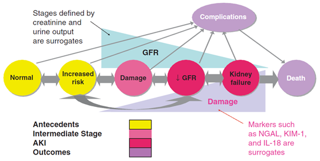

```
                                        Conceptual model for AKI (Murray et al, 2008)
```

## Packages installed

```python
import math
import numpy as np
import pandas as pd
import matplotlib
import matplotlib.pyplot as plt
import seaborn as sns

import statsmodels.api as sm
import statsmodels.formula.api as smf

from sklearn.model_selection import train_test_split
from sklearn.linear_model import LinearRegression
from sklearn.feature_selection import RFE
from sklearn.linear_model import RidgeCV, LassoCV, Ridge, Lasso
from sklearn.experimental import enable_iterative_imputer
from sklearn.impute import IterativeImputer

import tensorflow as tf
import torch

from catboost import CatBoostClassifier, Pool
```

```python
%matplotlib inline
```

## Upload dataset

```python
df_AKI = pd.read_csv('D:\\Pitt_1\\Research_0\\Data_AKI.csv')
```

```python
df_AKI.info()
```

```
<class 'pandas.core.frame.DataFrame'>
RangeIndex: 21876 entries, 0 to 21875
Columns: 162 entries, ICUSTAY_ID to PEAK_TIMEWINDOW24TO72
dtypes: float64(100), int64(61), object(1)
memory usage: 27.0+ MB
```

```python
names = list(df_AKI.columns)
df_AKI.describe().T
```

|  | count | mean | std | min | 25% | 50% | 75% | max |
| --- | --- | --- | --- | --- | --- | --- | --- | --- |
| ICUSTAY_ID | 21876.0 | 250218.920781 | 28854.067870 | 200001.0000 | 225294.0000 | 250406.0000 | 275181.2500 | 299998.000 |
| SUBJECT_ID | 21876.0 | 62454.738343 | 24210.433923 | 23.0000 | 47131.2500 | 64478.5000 | 82115.7500 | 99999.000 |
| HADM_ID | 21876.0 | 150153.701774 | 28789.596882 | 100001.0000 | 125300.7500 | 150365.0000 | 174972.5000 | 199999.000 |
| Gender | 21876.0 | 0.559060 | 0.496511 | 0.0000 | 0.0000 | 1.0000 | 1.0000 | 1.000 |
| Age_Patient | 21876.0 | 64.292329 | 17.143247 | 15.0000 | 53.0000 | 66.0000 | 78.0000 | 90.000 |
| ... | ... | ... | ... | ... | ... | ... | ... | ... |
| MECHANICAL_VENTILATION_ICD | 21876.0 | 0.291507 | 0.503159 | 0.0000 | 0.0000 | 0.0000 | 1.0000 | 4.000 |
| MECHANICAL_VENTILATION_PROCEDUREEVENTS_MV | 21876.0 | 0.382017 | 0.549222 | 0.0000 | 0.0000 | 0.0000 | 1.0000 | 11.000 |
| CONTRAST_ICD | 21876.0 | 0.003931 | 0.072715 | 0.0000 | 0.0000 | 0.0000 | 0.0000 | 3.000 |
| LOS | 21876.0 | 3.574740 | 4.966906 | 0.0012 | 1.1534 | 1.9811 | 3.7856 | 101.739 |
| PEAK_TIMEWINDOW24TO72 | 13569.0 | 75.307045 | 8584.697188 | 0.0000 | 0.7000 | 1.0000 | 1.6000 | 999999.000 |

161 rows × 8 columns

Height and BMI variables

```python
df_AKI[names[8:10]].describe().T
```

|  | count | mean | std | min | 25% | 50% | 75% | max |
| --- | --- | --- | --- | --- | --- | --- | --- | --- |
| Height_cm | 11679.0 | 168.724150 | 15.320516 | 0.0 | 163.000000 | 170.000000 | 178.000000 | 445.0 |
| BMI | 11679.0 | 33.314538 | 159.288771 | 0.0 | 23.767704 | 27.319211 | 31.741789 | 9090.0 |

```python
df_AKI[names[8:10]].isnull().sum()
```

```
Height_cm    10197
BMI          10197
dtype: int64
```

Vital Signs

```python
df_AKI[names[10:30]].describe().T
```

|  | count | mean | std | min | 25% | 50% | 75% | max |
| --- | --- | --- | --- | --- | --- | --- | --- | --- |
| FIRST_BP_SYSTOLIC | 19910.0 | 124.678001 | 25.231600 | 0.000000 | 107.000000 | 123.000000 | 141.000000 | 265.000000 |
| LAST_BP_SYSTOLIC | 19910.0 | 124.683426 | 847.617091 | 0.000000 | 103.000000 | 116.000000 | 132.000000 | 119119.020000 |
| VARIATION_BP_SYSTOLIC | 19910.0 | -0.322686 | 39.004257 | -104.000000 | -1.200000 | -0.272727 | 0.473684 | 5408.773636 |
| PEAK_BP_SYSTOLIV | 19910.0 | 156.423054 | 1241.278227 | 0.000000 | 125.000000 | 140.000000 | 157.000000 | 127105.990000 |
| MEAN_BP_SYSTOLIC | 19910.0 | 118.682314 | 55.306994 | 0.000000 | 105.000000 | 115.848077 | 129.372159 | 5527.500909 |
| FIRST_BP_DIASTOLIC | 19903.0 | 68.964226 | 83.536891 | 0.000000 | 56.000000 | 66.000000 | 78.000000 | 7793.000000 |
| LAST_BP_DIASTOLIC | 19903.0 | 62.618449 | 15.434954 | 0.000000 | 52.000000 | 61.000000 | 72.000000 | 176.000000 |
| VARIATION_BP_DIASTOLIC | 19903.0 | -0.766649 | 36.925174 | -5160.000000 | -0.869565 | -0.227273 | 0.294118 | 55.000000 |
| PEAK_BP_DIASTOLIC | 19903.0 | 111.893130 | 1280.096172 | 0.000000 | 71.000000 | 82.000000 | 95.000000 | 114108.980000 |
| MEAN_BP_DIASTOLIC | 19903.0 | 64.349896 | 59.505805 | 0.000000 | 54.958333 | 62.000000 | 70.200000 | 5285.680909 |
| FIRST_TEMPERATURE | 21036.0 | 36.515970 | 3.098183 | -17.777778 | 36.055556 | 36.555556 | 37.055556 | 101.100000 |
| LAST_TEMPERATURE | 21036.0 | 36.838473 | 4.591067 | -17.777778 | 36.388889 | 36.777778 | 37.222222 | 599.444444 |
| VARIATION_TEMPERATURE | 21036.0 | 0.017869 | 0.453873 | -33.722222 | -0.017544 | 0.008772 | 0.040741 | 40.234127 |
| PEAK_TEMPERATURE | 21036.0 | 37.756000 | 8.955377 | -17.777778 | 36.888889 | 37.277778 | 37.800000 | 599.444444 |
| MEAN_TEMPERATURE | 21036.0 | 36.722923 | 2.002698 | -17.777778 | 36.370370 | 36.722222 | 37.092593 | 148.900000 |
| FIRST_MAP | 8629.0 | 80.090354 | 39.817421 | -135.000000 | 68.000000 | 80.000000 | 93.000000 | 361.000000 |
| LAST_MAP | 8629.0 | 78.933905 | 28.742479 | -40.000000 | 68.000000 | 77.000000 | 87.000000 | 360.000000 |
| VARIATION_MAP | 8629.0 | -0.072793 | 9.064012 | -249.000000 | -0.913043 | -0.166667 | 0.555556 | 310.000000 |
| PEAK_MAP | 8629.0 | 111.090238 | 110.785347 | -39.000000 | 90.000000 | 100.000000 | 113.000000 | 9381.000000 |
| MEAN_MAP | 8629.0 | 79.155637 | 20.448761 | -39.000000 | 71.500000 | 77.551724 | 85.666667 | 414.217391 |

```python
df_AKI[names[10:30]].isnull().sum()
```

```
FIRST_BP_SYSTOLIC          1966
LAST_BP_SYSTOLIC           1966
VARIATION_BP_SYSTOLIC      1966
PEAK_BP_SYSTOLIV           1966
MEAN_BP_SYSTOLIC           1966
FIRST_BP_DIASTOLIC         1973
LAST_BP_DIASTOLIC          1973
VARIATION_BP_DIASTOLIC     1973
PEAK_BP_DIASTOLIC          1973
MEAN_BP_DIASTOLIC          1973
FIRST_TEMPERATURE           840
LAST_TEMPERATURE            840
VARIATION_TEMPERATURE       840
PEAK_TEMPERATURE            840
MEAN_TEMPERATURE            840
FIRST_MAP                 13247
LAST_MAP                  13247
VARIATION_MAP             13247
PEAK_MAP                  13247
MEAN_MAP                  13247
dtype: int64
```

Diagnosis variables

```python
df_AKI[names[30:64]].describe().T
```

|  | count | mean | std | min | 25% | 50% | 75% | max |
| --- | --- | --- | --- | --- | --- | --- | --- | --- |
| DIABETES_ICD | 21876.0 | 0.291598 | 0.454509 | 0.0 | 0.0 | 0.0 | 1.0 | 1.0 |
| HYPERTENSION_ICD | 21876.0 | 0.435683 | 0.495857 | 0.0 | 0.0 | 0.0 | 1.0 | 1.0 |
| CKD_ICD | 21876.0 | 0.197020 | 0.397756 | 0.0 | 0.0 | 0.0 | 0.0 | 1.0 |
| CONGESTIVEHEARTFAILURE_ICD | 21876.0 | 0.252788 | 0.434621 | 0.0 | 0.0 | 0.0 | 1.0 | 1.0 |
| HYPOTENSION_ICD | 21876.0 | 0.126577 | 0.332506 | 0.0 | 0.0 | 0.0 | 0.0 | 1.0 |
| SEPSIS_ICD | 21876.0 | 0.130691 | 0.337070 | 0.0 | 0.0 | 0.0 | 0.0 | 1.0 |
| OTHERINFECTION_ICD | 21876.0 | 0.190346 | 0.392583 | 0.0 | 0.0 | 0.0 | 0.0 | 1.0 |
| CHRONICLIVERDISEASE_ICD | 21876.0 | 0.098373 | 0.297825 | 0.0 | 0.0 | 0.0 | 0.0 | 1.0 |
| CHRONICLUNGDISEASE_ICD | 21876.0 | 0.415021 | 0.492737 | 0.0 | 0.0 | 0.0 | 1.0 | 1.0 |
| ANEMIA_ICD | 21876.0 | 0.376943 | 0.484631 | 0.0 | 0.0 | 0.0 | 1.0 | 1.0 |
| CARDIOVASCULARFAILURE_ICD | 21876.0 | 0.000046 | 0.006761 | 0.0 | 0.0 | 0.0 | 0.0 | 1.0 |
| OBSTRUCTIVEUROPATHY_ICD | 21876.0 | 0.054855 | 0.227702 | 0.0 | 0.0 | 0.0 | 0.0 | 1.0 |
| DIABETES_ADM | 21876.0 | 0.013119 | 0.113789 | 0.0 | 0.0 | 0.0 | 0.0 | 1.0 |
| HYPERTENSION_ADM | 21876.0 | 0.003748 | 0.061111 | 0.0 | 0.0 | 0.0 | 0.0 | 1.0 |
| CKD_ADM | 21876.0 | 0.000914 | 0.030223 | 0.0 | 0.0 | 0.0 | 0.0 | 1.0 |
| CONGESTIVEHEARTFAILURE_ADM | 21876.0 | 0.029622 | 0.169545 | 0.0 | 0.0 | 0.0 | 0.0 | 1.0 |
| HYPOTENSION_ADM | 21876.0 | 0.017325 | 0.130482 | 0.0 | 0.0 | 0.0 | 0.0 | 1.0 |
| SEPSIS_ADM | 21876.0 | 0.031861 | 0.175635 | 0.0 | 0.0 | 0.0 | 0.0 | 1.0 |
| OTHERINFECTION_ADM | 21876.0 | 0.001874 | 0.043252 | 0.0 | 0.0 | 0.0 | 0.0 | 1.0 |
| CHRONICLIVERDISEASE_ADM | 21876.0 | 0.009142 | 0.095180 | 0.0 | 0.0 | 0.0 | 0.0 | 1.0 |
| CHRONICLUNGDISEASE_ADM | 21876.0 | 0.015176 | 0.122257 | 0.0 | 0.0 | 0.0 | 0.0 | 1.0 |
| ANEMIA_ADM | 21876.0 | 0.006994 | 0.083339 | 0.0 | 0.0 | 0.0 | 0.0 | 1.0 |
| OBSTRUCTIVEUROPATHY_ADM | 21876.0 | 0.000046 | 0.006761 | 0.0 | 0.0 | 0.0 | 0.0 | 1.0 |
| DIABETES_CHECK | 21876.0 | 0.721338 | 0.448351 | 0.0 | 0.0 | 1.0 | 1.0 | 1.0 |
| HYPERTENSION_CHECK | 21876.0 | 0.563403 | 0.495975 | 0.0 | 0.0 | 1.0 | 1.0 | 1.0 |
| CKD_CHECK | 21876.0 | 0.803895 | 0.397058 | 0.0 | 1.0 | 1.0 | 1.0 | 1.0 |
| CONGESTIVEHEARTFAILURE_CHECK | 21876.0 | 0.773359 | 0.418668 | 0.0 | 1.0 | 1.0 | 1.0 | 1.0 |
| HYPOTENSION_CHECK | 21876.0 | 0.868715 | 0.337720 | 0.0 | 1.0 | 1.0 | 1.0 | 1.0 |
| SEPSIS_CHECK | 21876.0 | 0.885994 | 0.317826 | 0.0 | 1.0 | 1.0 | 1.0 | 1.0 |
| OTHERINFECTION_CHECK | 21876.0 | 0.810523 | 0.391896 | 0.0 | 1.0 | 1.0 | 1.0 | 1.0 |
| CHRONICLIVERDISEASE_CHECK | 21876.0 | 0.909673 | 0.286657 | 0.0 | 1.0 | 1.0 | 1.0 | 1.0 |
| CHRONICLUNGDISEASE_CHECK | 21876.0 | 0.599607 | 0.489989 | 0.0 | 0.0 | 1.0 | 1.0 | 1.0 |
| ANEMIA_CHECK | 21876.0 | 0.629137 | 0.483047 | 0.0 | 0.0 | 1.0 | 1.0 | 1.0 |
| OBSTRUCTIVEUROPATHY_CHECK | 21876.0 | 0.945100 | 0.227791 | 0.0 | 1.0 | 1.0 | 1.0 | 1.0 |

```python
df_AKI[names[30:64]].isnull().sum()
```

```
DIABETES_ICD                    0
HYPERTENSION_ICD                0
CKD_ICD                         0
CONGESTIVEHEARTFAILURE_ICD      0
HYPOTENSION_ICD                 0
SEPSIS_ICD                      0
OTHERINFECTION_ICD              0
CHRONICLIVERDISEASE_ICD         0
CHRONICLUNGDISEASE_ICD          0
ANEMIA_ICD                      0
CARDIOVASCULARFAILURE_ICD       0
OBSTRUCTIVEUROPATHY_ICD         0
DIABETES_ADM                    0
HYPERTENSION_ADM                0
CKD_ADM                         0
CONGESTIVEHEARTFAILURE_ADM      0
HYPOTENSION_ADM                 0
SEPSIS_ADM                      0
OTHERINFECTION_ADM              0
CHRONICLIVERDISEASE_ADM         0
CHRONICLUNGDISEASE_ADM          0
ANEMIA_ADM                      0
OBSTRUCTIVEUROPATHY_ADM         0
DIABETES_CHECK                  0
HYPERTENSION_CHECK              0
CKD_CHECK                       0
CONGESTIVEHEARTFAILURE_CHECK    0
HYPOTENSION_CHECK               0
SEPSIS_CHECK                    0
OTHERINFECTION_CHECK            0
CHRONICLIVERDISEASE_CHECK       0
CHRONICLUNGDISEASE_CHECK        0
ANEMIA_CHECK                    0
OBSTRUCTIVEUROPATHY_CHECK       0
dtype: int64
```

Medication variables

```python
df_AKI[names[64:82]].describe().T
```

|  | count | mean | std | min | 25% | 50% | 75% | max |
| --- | --- | --- | --- | --- | --- | --- | --- | --- |
| ANTIBIOTICS | 21876.0 | 0.646690 | 0.478009 | 0.0 | 0.0 | 1.0 | 1.0 | 1.0 |
| DIURETICSLOOP_FUROSEMIDE | 21876.0 | 0.327071 | 0.469154 | 0.0 | 0.0 | 0.0 | 1.0 | 1.0 |
| VANCOMYCIN | 21876.0 | 0.389102 | 0.487558 | 0.0 | 0.0 | 0.0 | 1.0 | 1.0 |
| CALCINEURIN_INHIBITORS_CYCLOSPORINE | 21876.0 | 0.000457 | 0.021376 | 0.0 | 0.0 | 0.0 | 0.0 | 1.0 |
| AMPHOTERCIN | 21876.0 | 0.000000 | 0.000000 | 0.0 | 0.0 | 0.0 | 0.0 | 0.0 |
| ANTIBIOTICS.PRES | 21876.0 | 0.494835 | 0.499985 | 0.0 | 0.0 | 0.0 | 1.0 | 1.0 |
| DIURETICS.PRES | 21876.0 | 0.118395 | 0.323082 | 0.0 | 0.0 | 0.0 | 0.0 | 1.0 |
| ACEI.PRES | 21876.0 | 0.231807 | 0.421996 | 0.0 | 0.0 | 0.0 | 0.0 | 1.0 |
| NSAID.PRES | 21876.0 | 0.488892 | 0.499888 | 0.0 | 0.0 | 0.0 | 1.0 | 1.0 |
| ARB.PRES | 21876.0 | 0.034878 | 0.183476 | 0.0 | 0.0 | 0.0 | 0.0 | 1.0 |
| VANCOMYCIN.PRES | 21876.0 | 0.449397 | 0.497444 | 0.0 | 0.0 | 0.0 | 1.0 | 1.0 |
| DIURETICSLOOP.PRES | 21876.0 | 0.491269 | 0.499935 | 0.0 | 0.0 | 0.0 | 1.0 | 1.0 |
| CALCINEURININHIBITORS.PRES | 21876.0 | 0.020113 | 0.140391 | 0.0 | 0.0 | 0.0 | 0.0 | 1.0 |
| AMPHOTERCIN.PRES | 21876.0 | 0.000411 | 0.020280 | 0.0 | 0.0 | 0.0 | 0.0 | 1.0 |
| ANTIBIOTICS_BEFORE_24h | 21876.0 | 0.054992 | 0.227969 | 0.0 | 0.0 | 0.0 | 0.0 | 1.0 |
| DIURETICSLOOP_BEFORE_24h | 21876.0 | 0.019519 | 0.138344 | 0.0 | 0.0 | 0.0 | 0.0 | 1.0 |
| VANCOMYCIN_BEFORE_24h | 21876.0 | 0.013074 | 0.113593 | 0.0 | 0.0 | 0.0 | 0.0 | 1.0 |
| CALCEURIN_INHIBITORS_BEFORE_24h | 21876.0 | 0.000000 | 0.000000 | 0.0 | 0.0 | 0.0 | 0.0 | 0.0 |

```python
df_AKI[names[64:82]].isnull().sum()
```

```
ANTIBIOTICS                            0
DIURETICSLOOP_FUROSEMIDE               0
VANCOMYCIN                             0
CALCINEURIN_INHIBITORS_CYCLOSPORINE    0
AMPHOTERCIN                            0
ANTIBIOTICS.PRES                       0
DIURETICS.PRES                         0
ACEI.PRES                              0
NSAID.PRES                             0
ARB.PRES                               0
VANCOMYCIN.PRES                        0
DIURETICSLOOP.PRES                     0
CALCINEURININHIBITORS.PRES             0
AMPHOTERCIN.PRES                       0
ANTIBIOTICS_BEFORE_24h                 0
DIURETICSLOOP_BEFORE_24h               0
VANCOMYCIN_BEFORE_24h                  0
CALCEURIN_INHIBITORS_BEFORE_24h        0
dtype: int64
```

Lab tests variables

```python
df_AKI[names[82:167]].describe().T
```

|  | count | mean | std | min | 25% | 50% | 75% | max |
| --- | --- | --- | --- | --- | --- | --- | --- | --- |
| FIRST_SERUM_CREATININE | 21287.0 | 1.437713 | 1.606933 | 0.0000 | 0.700000 | 0.9000 | 1.4000 | 33.100 |
| LAST_SERUM_CREATININE | 21287.0 | 1.421995 | 1.876772 | 0.0000 | 0.700000 | 0.9000 | 1.4000 | 149.000 |
| VARIATION_SERUM_CREATININE | 21287.0 | -0.000401 | 0.180703 | -1.4000 | -0.004762 | 0.0000 | 0.0000 | 24.750 |
| PEAK_SERUM_CREATININE | 21287.0 | 1.549504 | 3.239018 | 0.0000 | 0.700000 | 1.0000 | 1.5000 | 293.000 |
| MEAN_SERUM_CREATININE | 21287.0 | 1.436703 | 1.730911 | 0.0000 | 0.700000 | 0.9500 | 1.4000 | 74.750 |
| ... | ... | ... | ... | ... | ... | ... | ... | ... |
| MECHANICAL_VENTILATION_ICD | 21876.0 | 0.291507 | 0.503159 | 0.0000 | 0.000000 | 0.0000 | 1.0000 | 4.000 |
| MECHANICAL_VENTILATION_PROCEDUREEVENTS_MV | 21876.0 | 0.382017 | 0.549222 | 0.0000 | 0.000000 | 0.0000 | 1.0000 | 11.000 |
| CONTRAST_ICD | 21876.0 | 0.003931 | 0.072715 | 0.0000 | 0.000000 | 0.0000 | 0.0000 | 3.000 |
| LOS | 21876.0 | 3.574740 | 4.966906 | 0.0012 | 1.153400 | 1.9811 | 3.7856 | 101.739 |
| PEAK_TIMEWINDOW24TO72 | 13569.0 | 75.307045 | 8584.697188 | 0.0000 | 0.700000 | 1.0000 | 1.6000 | 999999.000 |

80 rows × 8 columns

```python
df_AKI[names[82:167]].isnull().sum()
```

```
FIRST_SERUM_CREATININE                        589
LAST_SERUM_CREATININE                         589
VARIATION_SERUM_CREATININE                    589
PEAK_SERUM_CREATININE                         589
MEAN_SERUM_CREATININE                         589
                                             ...
MECHANICAL_VENTILATION_ICD                      0
MECHANICAL_VENTILATION_PROCEDUREEVENTS_MV       0
CONTRAST_ICD                                    0
LOS                                             0
PEAK_TIMEWINDOW24TO72                        8307
Length: 80, dtype: int64
```

## Dataset preprocessing

- Instance inclusion and exclusion
  - Using data within 24h after ICU admission to predict whether AKI will occur within the next 48h.

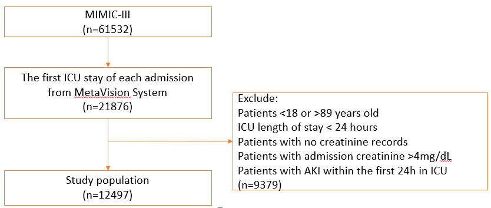

So we need to exclude the data points in the "Exclude" part.

```python
df_AKI["Age_Patient"].head()
```

```
0    61
1    27
2    84
3    67
4    60
Name: Age_Patient, dtype: int64
```

```python
df_AKI.info()
```

```
<class 'pandas.core.frame.DataFrame'>
RangeIndex: 21876 entries, 0 to 21875
Columns: 162 entries, ICUSTAY_ID to PEAK_TIMEWINDOW24TO72
dtypes: float64(100), int64(61), object(1)
memory usage: 27.0+ MB
```

```python
### Exclude patients <18 or >89 years old
df_AKI = df_AKI[(df_AKI["Age_Patient"] >= 18) & (df_AKI["Age_Patient"] <= 89)]
```

```python
for col in df_AKI.columns:
    print(col)
```

```
ICUSTAY_ID
SUBJECT_ID
HADM_ID
INTIME
Gender
Age_Patient
Race
Admission.Weight..kg.
Height_cm
BMI
FIRST_BP_SYSTOLIC
LAST_BP_SYSTOLIC
VARIATION_BP_SYSTOLIC
PEAK_BP_SYSTOLIV
MEAN_BP_SYSTOLIC
FIRST_BP_DIASTOLIC
LAST_BP_DIASTOLIC
VARIATION_BP_DIASTOLIC
PEAK_BP_DIASTOLIC
MEAN_BP_DIASTOLIC
FIRST_TEMPERATURE
LAST_TEMPERATURE
VARIATION_TEMPERATURE
PEAK_TEMPERATURE
MEAN_TEMPERATURE
FIRST_MAP
LAST_MAP
VARIATION_MAP
PEAK_MAP
MEAN_MAP
DIABETES_ICD
HYPERTENSION_ICD
CKD_ICD
CONGESTIVEHEARTFAILURE_ICD
HYPOTENSION_ICD
SEPSIS_ICD
OTHERINFECTION_ICD
CHRONICLIVERDISEASE_ICD
CHRONICLUNGDISEASE_ICD
ANEMIA_ICD
```

[output cut: 107 more lines]

```
FIRST_AST
LAST_AST
VARIATION_AST
PEAK_AST
MEAN_AST
FIRST_CALCIUM
LAST_CALCIUM
VARIATION_CALCIUM
PEAK_CALCIUM
MEAN_CALCIUM
MECHANICAL_VENTILATION_ICD
MECHANICAL_VENTILATION_PROCEDUREEVENTS_MV
CONTRAST_ICD
LOS
PEAK_TIMEWINDOW24TO72
```

```python
len(np.unique(df_AKI["ICUSTAY_ID"]))
```

```
20667
```

```python
df_AKI["FIRST_SERUM_CREATININE"].head()
```

```
0    2.7
1    0.9
2    2.0
3    0.7
4    0.8
Name: FIRST_SERUM_CREATININE, dtype: float64
```

```python
### Exclude patients with no creatinine records
df_AKI = df_AKI[(df_AKI["FIRST_SERUM_CREATININE"].notna())]
```

```python
df_AKI = df_AKI[(df_AKI["LAST_SERUM_CREATININE"].notna())]
```

```python
### Exclude patients with admission creatinine >= 4mg/dL
df_AKI = df_AKI[df_AKI["FIRST_SERUM_CREATININE"] <= 4.0]
```

```python
df_AKI.info()
```

```
<class 'pandas.core.frame.DataFrame'>
Int64Index: 18991 entries, 0 to 21875
Columns: 162 entries, ICUSTAY_ID to PEAK_TIMEWINDOW24TO72
dtypes: float64(100), int64(61), object(1)
memory usage: 23.6+ MB
```

```python
### Exclude patients whose ICU length of staying less than 24 hours
df_AKI = df_AKI[df_AKI["LOS"] >= 1]
```

```python
df_AKI.info()
```

```
<class 'pandas.core.frame.DataFrame'>
Int64Index: 16118 entries, 0 to 21875
Columns: 162 entries, ICUSTAY_ID to PEAK_TIMEWINDOW24TO72
dtypes: float64(100), int64(61), object(1)
memory usage: 20.0+ MB
```

- We are going to use KDIGO Clinical Practice Guidelines for Acute Kidney Injury (AKI).
  1. Increase in serum creatinine by $\geq$0.3 mg/dl within 48h
  2. Increase in serum creatinine to $\geq$1.5 times baseline, which is known or presumed to have occurred within the prior 7 days
  3. Urine volume $\leq$0.5 ml/kg/h for 6h

We are going to use the first one of KDIGO Clinical Practice Guidelines for AKI.

```python
df_AKI["SCR_diff"] = df_AKI["LAST_SERUM_CREATININE"] - df_AKI["FIRST_SERUM_CREATININE"]
```

```python
df_AKI["SCR_diff_1"] = df_AKI["PEAK_SERUM_CREATININE"] - df_AKI["FIRST_SERUM_CREATININE"]
```

```python
df_AKI.info()
```

```
<class 'pandas.core.frame.DataFrame'>
Int64Index: 16118 entries, 0 to 21875
Columns: 164 entries, ICUSTAY_ID to SCR_diff_1
dtypes: float64(102), int64(61), object(1)
memory usage: 20.3+ MB
```

Define the AKI status of all patients

```python
df_AKI["AKI_status"] = 0
```

```python
for i in range(len(df_AKI)):
    if df_AKI["SCR_diff_1"].iloc[i] >= 0.3:
        df_AKI["AKI_status"].iloc[i] = 1
```

```python
### Exclude Patients with AKI within the first 24h in ICU
df_AKI = df_AKI[df_AKI["AKI_status"] == 0]
```

```python
df_AKI.info()
```

```
<class 'pandas.core.frame.DataFrame'>
Int64Index: 15081 entries, 0 to 21875
Columns: 165 entries, ICUSTAY_ID to AKI_status
dtypes: float64(102), int64(62), object(1)
memory usage: 19.1+ MB
```

```python
df_AKI = df_AKI[df_AKI["PEAK_TIMEWINDOW24TO72"].notna()]
```

```python
for i in range(len(df_AKI)):
    if df_AKI["PEAK_TIMEWINDOW24TO72"].iloc[i] - df_AKI["LAST_SERUM_CREATININE"].iloc[i] >= 0.3:
        df_AKI["AKI_status"].iloc[i] = 1
```

=====================================

```python
df_AKI["AKI_status"]
```

```
0        1
2        0
5        0
6        0
7        0
        ..
21870    0
21871    0
21872    0
21874    0
21875    0
Name: AKI_status, Length: 10985, dtype: int64
```

```python
df_AKI["PEAK_TIMEWINDOW24TO72"].isna()
```

```
0        False
2        False
5        False
6        False
7        False
         ...
21870    False
21871    False
21872    False
21874    False
21875    False
Name: PEAK_TIMEWINDOW24TO72, Length: 10985, dtype: bool
```

```python
df_AKI.info()
```

```
<class 'pandas.core.frame.DataFrame'>
Int64Index: 10985 entries, 0 to 21875
Columns: 165 entries, ICUSTAY_ID to AKI_status
dtypes: float64(102), int64(62), object(1)
memory usage: 13.9+ MB
```

```python
len(df_AKI[df_AKI["AKI_status"] == 1])
```

```
1242
```

```python
df_AKI["AKI_status"]
```

```
0        1
2        0
5        0
6        0
7        0
        ..
21870    0
21871    0
21872    0
21874    0
21875    0
Name: AKI_status, Length: 10985, dtype: int64
```

Calculate the estimated glomerular filtration rate (eGFR)

```python
df_AKI["eGFR"] = 0
```

```python
df_AKI["Race"].value_counts()
```

```
5    8120
6    1087
3    1009
4     464
2     297
1       8
Name: Race, dtype: int64
```

```python
for i in range(len(df_AKI)):
    if df_AKI["Gender"].iloc[i] == 0:
        if df_AKI["Race"].iloc[i] == 3:
            df_AKI["eGFR"].iloc[i] = 175 * (df_AKI["LAST_SERUM_CREATININE"].iloc[i] ** -1.154) * (df_AKI["Age_Patient"].iloc[i] ** -0.203) * 0.742 * 1.212
        else:
            df_AKI["eGFR"].iloc[i] = 175 * (df_AKI["LAST_SERUM_CREATININE"].iloc[i] ** -1.154) * (df_AKI["Age_Patient"].iloc[i] ** -0.203) * 0.742

    else:
        if df_AKI["Race"].iloc[i] == 3:
            df_AKI["eGFR"].iloc[i] = 175 * (df_AKI["LAST_SERUM_CREATININE"].iloc[i] ** -1.154) * (df_AKI["Age_Patient"].iloc[i] ** -0.203) * 1.212
        else:
            df_AKI["eGFR"].iloc[i] = 175 * (df_AKI["LAST_SERUM_CREATININE"].iloc[i] ** -1.154) * (df_AKI["Age_Patient"].iloc[i] ** -0.203)
```

```python
df_AKI["eGFR"]
```

```
0         17.915388
2         30.708514
5         67.181466
6        112.486842
7        128.574438
            ...
21870     81.356762
21871     52.423272
21872     85.356011
21874     97.017659
21875     63.321105
Name: eGFR, Length: 10985, dtype: float64
```

## Feature Selection

- Using the last values of each time-independent featurea

```python
names_select = ['Gender', 'Age_Patient', 'Race', 'BMI',
                'LAST_BP_SYSTOLIC', 'LAST_BP_DIASTOLIC',
                'LAST_TEMPERATURE', 'LAST_MAP', 'DIABETES_ICD', 'HYPERTENSION_ICD', 'CKD_ICD',
                'CONGESTIVEHEARTFAILURE_ICD', 'HYPOTENSION_ICD', 'SEPSIS_ICD',
                'OTHERINFECTION_ICD', 'CHRONICLIVERDISEASE_ICD', 'CHRONICLUNGDISEASE_ICD',
                'ANEMIA_ICD', 'CARDIOVASCULARFAILURE_ICD', 'OBSTRUCTIVEUROPATHY_ICD',
                'ANTIBIOTICS_BEFORE_24h', 'DIURETICSLOOP_BEFORE_24h',
                'VANCOMYCIN_BEFORE_24h', 'LAST_SERUM_CREATININE', 'LAST_ALBUMIN', 'LAST_GFR_MDRD',
                'LAST_GLUCOSE_BLOOD', 'LAST_BILIRUBIN',
                'LAST_BUN', 'LAST_HEMOGLOBIN', 'LAST_SODIUM_SERUM', 'LAST_BICARBONATE', 'LAST_HEMATOCRIT',
                'LAST_PLATELET_COUNT', 'LAST_WBC',
                'LAST_AST', 'LAST_CALCIUM',
                'MECHANICAL_VENTILATION_ICD', 'MECHANICAL_VENTILATION_PROCEDUREEVENTS_MV', 'PEAK_TIMEWINDOW24TO72',
                'AKI_status', 'eGFR']
```

```python
df_AKI_1 = df_AKI[names_select]
```

```python
df_AKI_1.info()
```

```
<class 'pandas.core.frame.DataFrame'>
Int64Index: 10985 entries, 0 to 21875
Data columns (total 42 columns):
 #   Column                                     Non-Null Count  Dtype
---  ------                                     --------------  -----
 0   Gender                                     10985 non-null  int64
 1   Age_Patient                                10985 non-null  int64
 2   Race                                       10985 non-null  int64
 3   BMI                                        6614 non-null   float64
 4   LAST_BP_SYSTOLIC                           9825 non-null   float64
 5   LAST_BP_DIASTOLIC                          9821 non-null   float64
 6   LAST_TEMPERATURE                           10499 non-null  float64
 7   LAST_MAP                                   4927 non-null   float64
 8   DIABETES_ICD                               10985 non-null  int64
 9   HYPERTENSION_ICD                           10985 non-null  int64
```

[output cut: 34 more lines]

```python
df_AKI_1 = df_AKI_1[(df_AKI_1["BMI"] < 100.0) & (df_AKI_1["LAST_GLUCOSE_BLOOD"] < 1000.0)]
```

```python
df_AKI_1.info()
```

```
<class 'pandas.core.frame.DataFrame'>
Int64Index: 6520 entries, 0 to 21875
Data columns (total 42 columns):
 #   Column                                     Non-Null Count  Dtype
---  ------                                     --------------  -----
 0   Gender                                     6520 non-null   int64
 1   Age_Patient                                6520 non-null   int64
 2   Race                                       6520 non-null   int64
 3   BMI                                        6520 non-null   float64
 4   LAST_BP_SYSTOLIC                           5594 non-null   float64
 5   LAST_BP_DIASTOLIC                          5591 non-null   float64
 6   LAST_TEMPERATURE                           6080 non-null   float64
 7   LAST_MAP                                   3438 non-null   float64
 8   DIABETES_ICD                               6520 non-null   int64
 9   HYPERTENSION_ICD                           6520 non-null   int64
```

[output cut: 34 more lines]

- Missing values
  - Drop variables with more than 40% missing values
  - Multiple Imputation by Chained Equations (MICE)

```python
df_AKI_1["LAST_ALBUMIN"].isnull().sum()
```

```
4378
```

```python
len(df_AKI_1)
```

```
6520
```

```python
drop_list = []
```

```python
for i in names_select:
    if (df_AKI_1[i].isnull().sum()/len(df_AKI_1)) > 0.4:
        drop_list.append(i)
```

```python
drop_list
```

```
['LAST_MAP', 'LAST_ALBUMIN', 'LAST_BILIRUBIN', 'LAST_HEMOGLOBIN', 'LAST_AST']
```

```python
df_AKI_1 = df_AKI_1.drop(drop_list, axis = 1)
```

```python
df_AKI_1.info()
```

```
<class 'pandas.core.frame.DataFrame'>
Int64Index: 6520 entries, 0 to 21875
Data columns (total 37 columns):
 #   Column                                     Non-Null Count  Dtype
---  ------                                     --------------  -----
 0   Gender                                     6520 non-null   int64
 1   Age_Patient                                6520 non-null   int64
 2   Race                                       6520 non-null   int64
 3   BMI                                        6520 non-null   float64
 4   LAST_BP_SYSTOLIC                           5594 non-null   float64
 5   LAST_BP_DIASTOLIC                          5591 non-null   float64
 6   LAST_TEMPERATURE                           6080 non-null   float64
 7   DIABETES_ICD                               6520 non-null   int64
 8   HYPERTENSION_ICD                           6520 non-null   int64
 9   CKD_ICD                                    6520 non-null   int64
```

[output cut: 29 more lines]

```python
df_AKI_1["MECHANICAL_VENTILATION_ICD"]
```

[output not shown]

```python
import statsmodels
```

```python
imp = statsmodels.imputation.mice.MICEData(df_AKI_1)
```

```python
imp
```

```
<statsmodels.imputation.mice.MICEData at 0x2671034d160>
```

```python
imp_1 = IterativeImputer(max_iter = 10, random_state = 0)
```

```python
df_AKI_1['eGFR'].value_counts()
```

```
84.425720     19
85.786754     18
84.168388     17
113.180993    17
67.181466     17
              ..
40.903212      1
54.303415      1
64.817430      1
16.089713      1
inf            1
Name: eGFR, Length: 2427, dtype: int64
```

```python
df_AKI_1['eGFR'].describe()
```

```
count    6520.000000
mean             inf
std              NaN
min        10.745887
25%        51.180905
50%        75.469577
75%       101.632698
max              inf
Name: eGFR, dtype: float64
```

```python
df_AKI_1.loc[df_AKI_1['eGFR'] == math.inf]
```

|  | Gender | Age_Patient | Race | BMI | LAST_BP_SYSTOLIC | LAST_BP_DIASTOLIC | LAST_TEMPERATURE | DIABETES_ICD | HYPERTENSION_ICD | CKD_ICD | ... | LAST_BICARBONATE | LAST_HEMATOCRIT | LAST_PLATELET_COUNT | LAST_WBC | LAST_CALCIUM | MECHANICAL_VENTILATION_ICD | MECHANICAL_VENTILATION_PROCEDUREEVENTS_MV | PEAK_TIMEWINDOW24TO72 | AKI_status | eGFR |
| --- | --- | --- | --- | --- | --- | --- | --- | --- | --- | --- | --- | --- | --- | --- | --- | --- | --- | --- | --- | --- | --- |
| 11777 | 1 | 44 | 5 | 36.636735 | 87.0 | 46.0 | 36.944444 | 0 | 0 | 0 | ... | 17.0 | 35.5 | 189.0 | 6.7 | 8.6 | 1 | 1 | 0.2 | 0 | inf |

1 rows × 37 columns

```python
for i in range(len(df_AKI_1)):
    if df_AKI_1['eGFR'].iloc[i] == math.inf:
        df_AKI_1['eGFR'].iloc[i] = 200
```

```python
imp_1.fit(df_AKI_1)
```

```
IterativeImputer(random_state=0)
```

```python
m = imp_1.transform(df_AKI_1)
```

```python
df_AKI_1.head()
```

|  | Gender | Age_Patient | Race | BMI | LAST_BP_SYSTOLIC | LAST_BP_DIASTOLIC | LAST_TEMPERATURE | DIABETES_ICD | HYPERTENSION_ICD | CKD_ICD | ... | LAST_BICARBONATE | LAST_HEMATOCRIT | LAST_PLATELET_COUNT | LAST_WBC | LAST_CALCIUM | MECHANICAL_VENTILATION_ICD | MECHANICAL_VENTILATION_PROCEDUREEVENTS_MV | PEAK_TIMEWINDOW24TO72 | AKI_status | eGFR |
| --- | --- | --- | --- | --- | --- | --- | --- | --- | --- | --- | --- | --- | --- | --- | --- | --- | --- | --- | --- | --- | --- |
| 0 | 0 | 61 | 2 | 21.107266 | 97.0 | 55.0 | 37.555556 | 1 | 0 | 1 | ... | 28.0 | 23.6 | 128.0 | 2.8 | 8.5 | 0 | 0 | 3.5 | 1 | 17.915388 |
| 6 | 1 | 67 | 5 | 24.725183 | 115.0 | 71.0 | 36.555556 | 1 | 1 | 0 | ... | 24.0 | 36.6 | 165.0 | 11.8 | 8.0 | 1 | 0 | 0.7 | 0 | 112.486842 |
| 17 | 1 | 56 | 5 | 37.103007 | 148.0 | 50.0 | 36.166667 | 0 | 1 | 0 | ... | 24.0 | 37.9 | 279.0 | 7.5 | 9.3 | 0 | 0 | 1.1 | 0 | 77.295797 |
| 18 | 0 | 83 | 5 | 22.695312 | 94.0 | 46.0 | 36.277778 | 0 | 0 | 0 | ... | 17.0 | 31.7 | 131.0 | 30.7 | 7.9 | 0 | 1 | 0.6 | 0 | 79.914569 |
| 24 | 1 | 80 | 5 | 22.052190 | 126.0 | 53.0 | 36.444444 | 0 | 0 | 0 | ... | 22.0 | 32.2 | 71.0 | 8.9 | 7.9 | 0 | 0 | 1.1 | 0 | 58.255324 |

5 rows × 37 columns

```python
m = imp_1.transform(df_AKI_1)
```

```python
print(m)
```

```
[[  0.          61.           2.         ...   3.5          1.
   17.91538781]
 [  1.          67.           5.         ...   0.7          0.
  112.4868423 ]
 [  1.          56.           5.         ...   1.1          0.
   77.29579694]
 ...
 [  1.          56.           5.         ...   1.6          0.
   52.42327225]
 [  0.          60.           5.         ...   0.9          0.
   85.35601125]
 [  1.          87.           5.         ...   1.           0.
   63.32110452]]
```

```python
array_sum = np.sum(m)
array_has_nan = np.isnan(array_sum)
```

```python
print(array_has_nan)
```

```
False
```

```python
m = pd.DataFrame(m)
```

```python
m
```

|  | 0 | 1 | 2 | 3 | 4 | 5 | 6 | 7 | 8 | 9 | ... | 27 | 28 | 29 | 30 | 31 | 32 | 33 | 34 | 35 | 36 |
| --- | --- | --- | --- | --- | --- | --- | --- | --- | --- | --- | --- | --- | --- | --- | --- | --- | --- | --- | --- | --- | --- |
| 0 | 0.0 | 61.0 | 2.0 | 21.107266 | 97.000000 | 55.000000 | 37.555556 | 1.0 | 0.0 | 1.0 | ... | 28.0 | 23.6 | 128.0 | 2.8 | 8.5 | 0.0 | 0.0 | 3.5 | 1.0 | 17.915388 |
| 1 | 1.0 | 67.0 | 5.0 | 24.725183 | 115.000000 | 71.000000 | 36.555556 | 1.0 | 1.0 | 0.0 | ... | 24.0 | 36.6 | 165.0 | 11.8 | 8.0 | 1.0 | 0.0 | 0.7 | 0.0 | 112.486842 |
| 2 | 1.0 | 56.0 | 5.0 | 37.103007 | 148.000000 | 50.000000 | 36.166667 | 0.0 | 1.0 | 0.0 | ... | 24.0 | 37.9 | 279.0 | 7.5 | 9.3 | 0.0 | 0.0 | 1.1 | 0.0 | 77.295797 |
| 3 | 0.0 | 83.0 | 5.0 | 22.695312 | 94.000000 | 46.000000 | 36.277778 | 0.0 | 0.0 | 0.0 | ... | 17.0 | 31.7 | 131.0 | 30.7 | 7.9 | 0.0 | 1.0 | 0.6 | 0.0 | 79.914569 |
| 4 | 1.0 | 80.0 | 5.0 | 22.052190 | 126.000000 | 53.000000 | 36.444444 | 0.0 | 0.0 | 0.0 | ... | 22.0 | 32.2 | 71.0 | 8.9 | 7.9 | 0.0 | 0.0 | 1.1 | 0.0 | 58.255324 |
| ... | ... | ... | ... | ... | ... | ... | ... | ... | ... | ... | ... | ... | ... | ... | ... | ... | ... | ... | ... | ... | ... |
| 6515 | 1.0 | 23.0 | 5.0 | 24.933720 | 114.970745 | 65.816191 | 37.666667 | 0.0 | 0.0 | 0.0 | ... | 27.0 | 25.6 | 229.0 | 26.0 | 9.2 | 1.0 | 1.0 | 0.8 | 0.0 | 104.571044 |
| 6516 | 0.0 | 76.0 | 2.0 | 26.878463 | 104.000000 | 52.000000 | 36.611111 | 0.0 | 1.0 | 0.0 | ... | 25.0 | 37.2 | 317.0 | 15.5 | 8.1 | 0.0 | 0.0 | 0.6 | 0.0 | 81.356762 |
| 6517 | 1.0 | 56.0 | 5.0 | 40.346021 | 128.000000 | 52.000000 | 37.555556 | 0.0 | 0.0 | 1.0 | ... | 31.0 | 25.3 | 104.0 | 155.9 | 8.4 | 1.0 | 1.0 | 1.6 | 0.0 | 52.423272 |
| 6518 | 0.0 | 60.0 | 5.0 | 27.033976 | 96.000000 | 51.000000 | 37.055556 | 1.0 | 1.0 | 0.0 | ... | 30.0 | 27.9 | 136.0 | 7.7 | 7.9 | 0.0 | 1.0 | 0.9 | 0.0 | 85.356011 |
| 6519 | 1.0 | 87.0 | 5.0 | 29.228395 | 130.000000 | 48.000000 | 36.666667 | 1.0 | 1.0 | 0.0 | ... | 24.0 | 28.2 | 196.0 | 9.9 | 8.7 | 0.0 | 1.0 | 1.0 | 0.0 | 63.321105 |

6520 rows × 37 columns

```python
m.columns = ['Gender', 'Age_Patient', 'Race', 'BMI', 'LAST_BP_SYSTOLIC', 'LAST_BP_DIASTOLIC',
            'LAST_TEMPERATURE', 'DIABETES_ICD', 'HYPERTENSION_ICD', 'CKD_ICD',
            'CONGESTIVEHEARTFAILURE_ICD', 'HYPOTENSION_ICD', 'SEPSIS_ICD',
            'OTHERINFECTION_ICD', 'CHRONICLIVERDISEASE_ICD', 'CHRONICLUNGDISEASE_ICD',
            'ANEMIA_ICD', 'CARDIOVASCULARFAILURE_ICD', 'OBSTRUCTIVEUROPATHY_ICD',
            'ANTIBIOTICS_BEFORE_24h', 'DIURETICSLOOP_BEFORE_24h',
            'VANCOMYCIN_BEFORE_24h', 'LAST_SERUM_CREATININE', 'LAST_GFR_MDRD',
            'LAST_GLUCOSE_BLOOD',
            'LAST_BUN', 'LAST_SODIUM_SERUM', 'LAST_BICARBONATE', 'LAST_HEMATOCRIT',
            'LAST_PLATELET_COUNT', 'LAST_WBC',
            'LAST_CALCIUM',
            'MECHANICAL_VENTILATION_ICD', 'MECHANICAL_VENTILATION_PROCEDUREEVENTS_MV', 'PEAK_TIMEWINDOW24TO72',
            'AKI_status', 'eGFR']
```

```python
m
```

|  | Gender | Age_Patient | Race | BMI | LAST_BP_SYSTOLIC | LAST_BP_DIASTOLIC | LAST_TEMPERATURE | DIABETES_ICD | HYPERTENSION_ICD | CKD_ICD | ... | LAST_BICARBONATE | LAST_HEMATOCRIT | LAST_PLATELET_COUNT | LAST_WBC | LAST_CALCIUM | MECHANICAL_VENTILATION_ICD | MECHANICAL_VENTILATION_PROCEDUREEVENTS_MV | PEAK_TIMEWINDOW24TO72 | AKI_status | eGFR |
| --- | --- | --- | --- | --- | --- | --- | --- | --- | --- | --- | --- | --- | --- | --- | --- | --- | --- | --- | --- | --- | --- |
| 0 | 0.0 | 61.0 | 2.0 | 21.107266 | 97.000000 | 55.000000 | 37.555556 | 1.0 | 0.0 | 1.0 | ... | 28.0 | 23.6 | 128.0 | 2.8 | 8.5 | 0.0 | 0.0 | 3.5 | 1.0 | 17.915388 |
| 1 | 1.0 | 67.0 | 5.0 | 24.725183 | 115.000000 | 71.000000 | 36.555556 | 1.0 | 1.0 | 0.0 | ... | 24.0 | 36.6 | 165.0 | 11.8 | 8.0 | 1.0 | 0.0 | 0.7 | 0.0 | 112.486842 |
| 2 | 1.0 | 56.0 | 5.0 | 37.103007 | 148.000000 | 50.000000 | 36.166667 | 0.0 | 1.0 | 0.0 | ... | 24.0 | 37.9 | 279.0 | 7.5 | 9.3 | 0.0 | 0.0 | 1.1 | 0.0 | 77.295797 |
| 3 | 0.0 | 83.0 | 5.0 | 22.695312 | 94.000000 | 46.000000 | 36.277778 | 0.0 | 0.0 | 0.0 | ... | 17.0 | 31.7 | 131.0 | 30.7 | 7.9 | 0.0 | 1.0 | 0.6 | 0.0 | 79.914569 |
| 4 | 1.0 | 80.0 | 5.0 | 22.052190 | 126.000000 | 53.000000 | 36.444444 | 0.0 | 0.0 | 0.0 | ... | 22.0 | 32.2 | 71.0 | 8.9 | 7.9 | 0.0 | 0.0 | 1.1 | 0.0 | 58.255324 |
| ... | ... | ... | ... | ... | ... | ... | ... | ... | ... | ... | ... | ... | ... | ... | ... | ... | ... | ... | ... | ... | ... |
| 6515 | 1.0 | 23.0 | 5.0 | 24.933720 | 114.970745 | 65.816191 | 37.666667 | 0.0 | 0.0 | 0.0 | ... | 27.0 | 25.6 | 229.0 | 26.0 | 9.2 | 1.0 | 1.0 | 0.8 | 0.0 | 104.571044 |
| 6516 | 0.0 | 76.0 | 2.0 | 26.878463 | 104.000000 | 52.000000 | 36.611111 | 0.0 | 1.0 | 0.0 | ... | 25.0 | 37.2 | 317.0 | 15.5 | 8.1 | 0.0 | 0.0 | 0.6 | 0.0 | 81.356762 |
| 6517 | 1.0 | 56.0 | 5.0 | 40.346021 | 128.000000 | 52.000000 | 37.555556 | 0.0 | 0.0 | 1.0 | ... | 31.0 | 25.3 | 104.0 | 155.9 | 8.4 | 1.0 | 1.0 | 1.6 | 0.0 | 52.423272 |
| 6518 | 0.0 | 60.0 | 5.0 | 27.033976 | 96.000000 | 51.000000 | 37.055556 | 1.0 | 1.0 | 0.0 | ... | 30.0 | 27.9 | 136.0 | 7.7 | 7.9 | 0.0 | 1.0 | 0.9 | 0.0 | 85.356011 |
| 6519 | 1.0 | 87.0 | 5.0 | 29.228395 | 130.000000 | 48.000000 | 36.666667 | 1.0 | 1.0 | 0.0 | ... | 24.0 | 28.2 | 196.0 | 9.9 | 8.7 | 0.0 | 1.0 | 1.0 | 0.0 | 63.321105 |

6520 rows × 37 columns

```python
m.info()
```

```
<class 'pandas.core.frame.DataFrame'>
RangeIndex: 6520 entries, 0 to 6519
Data columns (total 37 columns):
 #   Column                                     Non-Null Count  Dtype
---  ------                                     --------------  -----
 0   Gender                                     6520 non-null   float64
 1   Age_Patient                                6520 non-null   float64
 2   Race                                       6520 non-null   float64
 3   BMI                                        6520 non-null   float64
 4   LAST_BP_SYSTOLIC                           6520 non-null   float64
 5   LAST_BP_DIASTOLIC                          6520 non-null   float64
 6   LAST_TEMPERATURE                           6520 non-null   float64
 7   DIABETES_ICD                               6520 non-null   float64
 8   HYPERTENSION_ICD                           6520 non-null   float64
 9   CKD_ICD                                    6520 non-null   float64
```

[output cut: 29 more lines]

- Categorizing the continuous variables as following

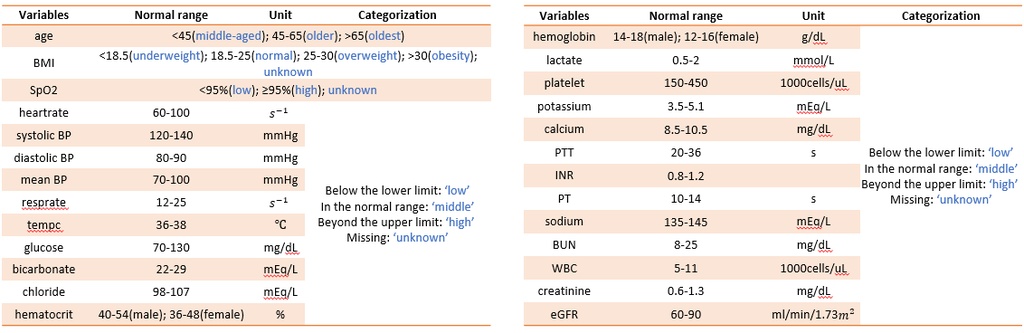

```python
m["age_indicator"] = '0'
m["BMI_indicator"] = '0'
m["sBP_indicator"] = '0'
m["dBP_indicator"] = '0'
m["temp_indicator"] = '0'
m["glucose_indicator"] = '0'
m["bicarbonate_indicator"] = '0'
m["hematocrit_indicator"] = '0'
m["platelet_indicator"] = '0'
m["calcium_indicator"] = '0'
m["sodium_indicator"] = '0'
m["BUN_indicator"] = '0'
m["WBC_indicator"] = '0'
m["creatinine_indicator"] = '0'
m['eGFR_indicator'] = '0'
```

```python
m['age_indicator']
```

```
0       0
1       0
2       0
3       0
4       0
       ..
6515    0
6516    0
6517    0
6518    0
6519    0
Name: age_indicator, Length: 6520, dtype: object
```

```python
for i in range(len(m)):
    if m["Age_Patient"][i] < 45:
        m["age_indicator"][i] = 'middle-aged'
    elif m["Age_Patient"][i] > 65:
        m["age_indicator"][i] = 'oldest'
    else:
        m["age_indicator"][i] = 'older'


for i in range(len(m)):
    if m["BMI"][i] < 18.5:
        m["BMI_indicator"][i] = 'underweight'
    elif m["BMI"][i] > 30:
        m["BMI_indicator"][i] = 'obesity'
    elif ((m["BMI"][i] >= 18.5) & (m["BMI"][i] <= 25)):
        m["BMI_indicator"][i] = 'normal'
    else:
        m["BMI_indicator"][i] = 'overweight'


for i in range(len(m)):
    if m["LAST_BP_SYSTOLIC"][i] < 120:
        m["sBP_indicator"][i] = 'low'
    elif m["LAST_BP_SYSTOLIC"][i] > 140:
        m["sBP_indicator"][i] = 'high'
    else:
        m["sBP_indicator"][i] = 'middle'

for i in range(len(m)):
    if m["LAST_BP_DIASTOLIC"][i] < 80:
        m["dBP_indicator"][i] = 'low'
    elif m["LAST_BP_DIASTOLIC"][i] > 90:
        m["dBP_indicator"][i] = 'high'
    else:
        m["dBP_indicator"][i] = 'middle'

for i in range(len(m)):
    if m["LAST_TEMPERATURE"][i] < 36:
        m["temp_indicator"][i] = 'low'
    elif m["LAST_TEMPERATURE"][i] > 38:
        m["temp_indicator"][i] = 'high'
    else:
        m["temp_indicator"][i] = 'middle'

for i in range(len(m)):
    if m["LAST_GLUCOSE_BLOOD"][i] < 70:
        m["glucose_indicator"][i] = 'low'
    elif m["LAST_GLUCOSE_BLOOD"][i] > 130:
        m["glucose_indicator"][i] = 'high'
    else:
        m["glucose_indicator"][i] = 'middle'

for i in range(len(m)):
    if m["LAST_BICARBONATE"][i] < 22:
        m["bicarbonate_indicator"][i] = 'low'
    elif m["LAST_BICARBONATE"][i] > 29:
        m["bicarbonate_indicator"][i] = 'high'
    else:
        m["bicarbonate_indicator"][i] = 'middle'


for i in range(len(m)):
    if m['Gender'][i] == 0:
        if m["LAST_HEMATOCRIT"][i] < 36:
            m["hematocrit_indicator"][i] = 'low'
        elif m["LAST_HEMATOCRIT"][i] > 48:
            m["hematocrit_indicator"][i] = 'high'
        else:
            m["hematocrit_indicator"][i] = 'middle'
    else:
        if m["LAST_HEMATOCRIT"][i] < 40:
            m["hematocrit_indicator"][i] = 'low'
        elif m["LAST_HEMATOCRIT"][i] > 54:
            m["hematocrit_indicator"][i] = 'high'
        else:
            m["hematocrit_indicator"][i] = 'middle'

for i in range(len(m)):
    if m["LAST_PLATELET_COUNT"][i] < 150:
        m["platelet_indicator"][i] = 'low'
    elif m["LAST_PLATELET_COUNT"][i] > 450:
        m["platelet_indicator"][i] = 'high'
    else:
        m["platelet_indicator"][i] = 'middle'
```

[output not shown]

[output cut: 75 more lines]

[output not shown]

```python
for i in range(len(m)):
    if m["LAST_CALCIUM"][i] < 8.5:
        m["calcium_indicator"][i] = 'low'
    elif m["LAST_CALCIUM"][i] > 10.5:
        m["calcium_indicator"][i] = 'high'
    else:
        m["calcium_indicator"][i] = 'middle'

for i in range(len(m)):
    if m["LAST_SODIUM_SERUM"][i] < 135:
        m["sodium_indicator"][i] = 'low'
    elif m["LAST_SODIUM_SERUM"][i] > 145:
        m["sodium_indicator"][i] = 'high'
    else:
        m["sodium_indicator"][i] = 'middle'

for i in range(len(m)):
    if m["LAST_BUN"][i] < 8:
        m["BUN_indicator"][i] = 'low'
    elif m["LAST_BUN"][i] > 25:
        m["BUN_indicator"][i] = 'high'
    else:
        m["BUN_indicator"][i] = 'middle'

for i in range(len(m)):
    if m["LAST_WBC"][i] < 5:
        m["WBC_indicator"][i] = 'low'
    elif m["LAST_WBC"][i] > 11:
        m["WBC_indicator"][i] = 'high'
    else:
        m["WBC_indicator"][i] = 'middle'

for i in range(len(m)):
    if m["LAST_SERUM_CREATININE"][i] < 0.6:
        m["creatinine_indicator"][i] = 'low'
    elif m["LAST_SERUM_CREATININE"][i] > 1.3:
        m["creatinine_indicator"][i] = 'high'
    else:
        m["creatinine_indicator"][i] = 'middle'

for i in range(len(m)):
    if m["eGFR"][i] < 60:
        m["eGFR_indicator"][i] = 'low'
    elif m["eGFR"][i] > 90:
        m["eGFR_indicator"][i] = 'high'
    else:
        m["eGFR_indicator"][i] = 'middle'
```

[output not shown]

[output cut: 23 more lines]

[output not shown]

```python
m['AKI_status'].value_counts()
```

```
0.0    5571
1.0     949
Name: AKI_status, dtype: int64
```

```python
5571 * 0.8
```

```
4456.8
```

## Handling class imbalance

- Using balanced class weight
  - Adjust weights inversely proportional to class frequencies in the input data
- Resampling
  - Over-sampling
    - Increase the number of instances from minority class
  - Under-sampling
    - Decrease the number of instances from majority class
  - Combine oversampling and under-sampling
- Over-sampling

```python
from sklearn.utils import resample
```

```python
m_majority = m[m["AKI_status"] == 0]
m_minority = m[m["AKI_status"] == 1]
```

```python
m_minority_os = resample(m_minority,
                         replace = True,
                         n_samples = 4457,
                         random_state = 123)
```

```python
m_overSample = pd.concat([m_majority, m_minority_os])
```

```python
m_overSample['AKI_status'].value_counts()
```

```
0.0    5571
1.0    4457
Name: AKI_status, dtype: int64
```

## CatBoost: gradient boosting with categorical features support

CatBoost is a state-of-the-art open-source gradient boosting on decision tree library.

Developed by Yandex researchers and engineers, it is the successor of the MatrixNet algorithm that is wisely used within the company for ranking tasks, forecasting and making recommendations. It is universal and can be applied across a wide range of areas and to a variety of problems.

```python
import os
import catboost
from catboost import *
```

```python
from catboost import cv
```

```python
names_cont = ['Gender', 'Age_Patient', 'Race', 'BMI', 'LAST_BP_SYSTOLIC', 'LAST_BP_DIASTOLIC',
              'LAST_TEMPERATURE', 'DIABETES_ICD', 'HYPERTENSION_ICD', 'CKD_ICD',
              'CONGESTIVEHEARTFAILURE_ICD', 'HYPOTENSION_ICD', 'SEPSIS_ICD',
              'OTHERINFECTION_ICD', 'CHRONICLIVERDISEASE_ICD', 'CHRONICLUNGDISEASE_ICD',
              'ANEMIA_ICD', 'CARDIOVASCULARFAILURE_ICD', 'OBSTRUCTIVEUROPATHY_ICD',
              'ANTIBIOTICS_BEFORE_24h', 'DIURETICSLOOP_BEFORE_24h',
              'VANCOMYCIN_BEFORE_24h', 'LAST_SERUM_CREATININE', 'LAST_GFR_MDRD',
              'LAST_GLUCOSE_BLOOD',
              'LAST_BUN', 'LAST_SODIUM_SERUM', 'LAST_BICARBONATE', 'LAST_HEMATOCRIT',
              'LAST_PLATELET_COUNT', 'LAST_WBC',
              'LAST_CALCIUM',
              'MECHANICAL_VENTILATION_ICD', 'PEAK_TIMEWINDOW24TO72',
              'AKI_status', 'eGFR']
```

```python
names_cate = ['Gender', "age_indicator", 'Race', "BMI_indicator", "sBP_indicator", "dBP_indicator",
              "temp_indicator", 'DIABETES_ICD', 'HYPERTENSION_ICD', 'CKD_ICD',
              'CONGESTIVEHEARTFAILURE_ICD', 'HYPOTENSION_ICD', 'SEPSIS_ICD',
              'OTHERINFECTION_ICD', 'CHRONICLIVERDISEASE_ICD', 'CHRONICLUNGDISEASE_ICD',
              'ANEMIA_ICD', 'CARDIOVASCULARFAILURE_ICD', 'OBSTRUCTIVEUROPATHY_ICD',
              'ANTIBIOTICS_BEFORE_24h', 'DIURETICSLOOP_BEFORE_24h',
              'VANCOMYCIN_BEFORE_24h', "creatinine_indicator",
              "glucose_indicator",
              "BUN_indicator", "sodium_indicator", "bicarbonate_indicator", "hematocrit_indicator",
              "platelet_indicator", "WBC_indicator",
              "calcium_indicator",
              'MECHANICAL_VENTILATION_ICD', 'PEAK_TIMEWINDOW24TO72',
              'AKI_status', "eGFR_indicator"]
```

```python
m_overSample_1 = m_overSample[names_cont]
```

```python
m_overSample_2 = m_overSample[names_cate]
```

```python
y = m_overSample_2.AKI_status
X = m_overSample_2.drop('AKI_status', axis = 1)
```

```python
X.shape
```

```
(10028, 34)
```

```python
X
```

|  | Gender | age_indicator | Race | BMI_indicator | sBP_indicator | dBP_indicator | temp_indicator | DIABETES_ICD | HYPERTENSION_ICD | CKD_ICD | ... | BUN_indicator | sodium_indicator | bicarbonate_indicator | hematocrit_indicator | platelet_indicator | WBC_indicator | calcium_indicator | MECHANICAL_VENTILATION_ICD | PEAK_TIMEWINDOW24TO72 | eGFR_indicator |
| --- | --- | --- | --- | --- | --- | --- | --- | --- | --- | --- | --- | --- | --- | --- | --- | --- | --- | --- | --- | --- | --- |
| 1 | 1.0 | oldest | 5.0 | normal | low | low | middle | 1.0 | 1.0 | 0.0 | ... | middle | middle | middle | low | middle | high | low | 1.0 | 0.7 | high |
| 2 | 1.0 | older | 5.0 | obesity | high | low | middle | 0.0 | 1.0 | 0.0 | ... | middle | middle | middle | low | middle | middle | middle | 0.0 | 1.1 | middle |
| 3 | 0.0 | oldest | 5.0 | normal | low | low | middle | 0.0 | 0.0 | 0.0 | ... | middle | middle | low | low | low | high | low | 0.0 | 0.6 | middle |
| 4 | 1.0 | oldest | 5.0 | normal | middle | low | middle | 0.0 | 0.0 | 0.0 | ... | middle | middle | middle | low | low | middle | low | 0.0 | 1.1 | low |
| 5 | 0.0 | oldest | 5.0 | obesity | high | low | middle | 1.0 | 1.0 | 0.0 | ... | middle | middle | middle | low | middle | high | middle | 1.0 | 0.8 | middle |
| ... | ... | ... | ... | ... | ... | ... | ... | ... | ... | ... | ... | ... | ... | ... | ... | ... | ... | ... | ... | ... | ... |
| 6337 | 1.0 | oldest | 5.0 | overweight | low | low | middle | 0.0 | 0.0 | 1.0 | ... | middle | middle | middle | low | low | high | low | 2.0 | 1.9 | middle |
| 2095 | 0.0 | oldest | 5.0 | obesity | low | low | middle | 0.0 | 0.0 | 1.0 | ... | middle | low | middle | low | low | middle | low | 0.0 | 1.3 | middle |
| 1536 | 1.0 | oldest | 5.0 | overweight | low | low | low | 1.0 | 1.0 | 1.0 | ... | middle | middle | middle | low | low | middle | low | 0.0 | 3.0 | low |
| 5169 | 1.0 | oldest | 5.0 | obesity | middle | low | middle | 1.0 | 1.0 | 0.0 | ... | middle | middle | middle | low | low | middle | middle | 1.0 | 1.1 | high |
| 3273 | 1.0 | oldest | 5.0 | overweight | high | high | low | 0.0 | 0.0 | 1.0 | ... | high | middle | low | low | low | high | low | 1.0 | 4.3 | low |

10028 rows × 34 columns

```python
# cat_features = list(range(0, X.shape[1]))
# print(cat_features)
```

[output not shown]

```python
print('Labels: {}'.format(set(y)))
print('Zero count = {}, Pme count = {}'.format(len(y) - sum(y), sum(y)))
```

```
Labels: {0.0, 1.0}
Zero count = 5571.0, Pme count = 4457.0
```

```python
from catboost.utils import create_cd
from catboost import CatBoostClassifier
```

```python
X_prepared = X.values.astype(str).astype(object)
```

```python
X_prepared
```

[output not shown]

```python
pool4 = Pool(
    data=FeaturesData(
        cat_feature_data=X_prepared,
        cat_feature_names=list(X)
    ),
    label=y.values
)

pool5 = Pool(
    data = X,
    label = y
)
```

```python
pool6 = Pool(
    data = X,
    label = y,
    cat_features = ["age_indicator", "BMI_indicator", "sBP_indicator", "dBP_indicator",
                    "temp_indicator", "creatinine_indicator", "glucose_indicator",
                    "BUN_indicator", "sodium_indicator", "bicarbonate_indicator", "hematocrit_indicator",
                    "platelet_indicator", "WBC_indicator", "calcium_indicator", "eGFR_indicator"]
)
```

```python
params = {}

params['loss_function'] = 'Logloss'
params['iterations'] = 80
params['custom_loss'] = 'AUC'
params['random_seed'] = 63
params['learning_rate'] = 0.5
```

```python
cv_data = cv(
    params = params,
    pool = pool6,
    fold_count=5,
    shuffle=True,
    partition_random_seed=0,
    plot=True,
    stratified=False,
    verbose=False
)
```

```python
cv_data.head()
```

|  | iterations | test-Logloss-mean | test-Logloss-std | train-Logloss-mean | train-Logloss-std | test-AUC-mean | test-AUC-std |
| --- | --- | --- | --- | --- | --- | --- | --- |
| 0 | 0 | 0.506309 | 0.013149 | 0.502784 | 0.009256 | 0.845109 | 0.012029 |
| 1 | 1 | 0.423189 | 0.047028 | 0.416850 | 0.038966 | 0.888624 | 0.026588 |
| 2 | 2 | 0.316901 | 0.019250 | 0.310669 | 0.012135 | 0.940101 | 0.010785 |
| 3 | 3 | 0.259751 | 0.015486 | 0.257962 | 0.013554 | 0.959042 | 0.005011 |
| 4 | 4 | 0.246404 | 0.012521 | 0.243356 | 0.012056 | 0.963184 | 0.003403 |

```python
best_value = np.max(cv_data['test-AUC-mean'])
best_iter = np.argmax(cv_data['test-AUC-mean'])

print('Best validation AUC, not stratified: {:.4f}±{:.4f} on step {}'.format(
    best_value,
    cv_data['test-AUC-std'][best_iter],
    best_iter)
)
```

```
Best validation AUC, not stratified: 0.9857±0.0020 on step 79
```

```python
best_iter
```

```
79
```

```python
model = CatBoostClassifier(
    iterations = best_iter,
    random_seed = 63,
    learning_rate = 0.5,
    custom_loss = ['AUC', 'Accuracy']
)
```

```python
model.fit(pool6)
```

```
0:	learn: 0.4977358	total: 18.3ms	remaining: 1.43s
1:	learn: 0.4084494	total: 31.8ms	remaining: 1.23s
2:	learn: 0.2976417	total: 48.4ms	remaining: 1.22s
3:	learn: 0.2631686	total: 64ms	remaining: 1.2s
4:	learn: 0.2478492	total: 79.3ms	remaining: 1.17s
5:	learn: 0.2265257	total: 95.6ms	remaining: 1.16s
6:	learn: 0.2191378	total: 111ms	remaining: 1.14s
7:	learn: 0.2109771	total: 124ms	remaining: 1.1s
8:	learn: 0.2027240	total: 139ms	remaining: 1.08s
9:	learn: 0.2013477	total: 151ms	remaining: 1.04s
10:	learn: 0.1962716	total: 166ms	remaining: 1.02s
11:	learn: 0.1947082	total: 177ms	remaining: 991ms
12:	learn: 0.1903226	total: 188ms	remaining: 952ms
13:	learn: 0.1847150	total: 198ms	remaining: 919ms
14:	learn: 0.1801715	total: 214ms	remaining: 914ms
15:	learn: 0.1801714	total: 220ms	remaining: 868ms
16:	learn: 0.1785474	total: 231ms	remaining: 844ms
17:	learn: 0.1734197	total: 244ms	remaining: 828ms
18:	learn: 0.1733382	total: 256ms	remaining: 809ms
19:	learn: 0.1719989	total: 270ms	remaining: 795ms
20:	learn: 0.1717524	total: 281ms	remaining: 775ms
21:	learn: 0.1652371	total: 293ms	remaining: 760ms
22:	learn: 0.1645168	total: 305ms	remaining: 743ms
23:	learn: 0.1582828	total: 318ms	remaining: 729ms
24:	learn: 0.1562690	total: 331ms	remaining: 714ms
25:	learn: 0.1513200	total: 344ms	remaining: 701ms
26:	learn: 0.1510219	total: 356ms	remaining: 685ms
27:	learn: 0.1507012	total: 367ms	remaining: 669ms
28:	learn: 0.1474879	total: 381ms	remaining: 658ms
29:	learn: 0.1452325	total: 397ms	remaining: 648ms
30:	learn: 0.1437466	total: 409ms	remaining: 634ms
31:	learn: 0.1405391	total: 425ms	remaining: 625ms
32:	learn: 0.1385601	total: 439ms	remaining: 612ms
33:	learn: 0.1377087	total: 450ms	remaining: 596ms
34:	learn: 0.1367912	total: 462ms	remaining: 581ms
35:	learn: 0.1341271	total: 480ms	remaining: 574ms
36:	learn: 0.1337575	total: 493ms	remaining: 560ms
37:	learn: 0.1315616	total: 506ms	remaining: 546ms
38:	learn: 0.1293836	total: 519ms	remaining: 532ms
39:	learn: 0.1281836	total: 532ms	remaining: 518ms
```

[output cut: 24 more lines]

```
64:	learn: 0.1024852	total: 869ms	remaining: 187ms
65:	learn: 0.0999277	total: 884ms	remaining: 174ms
66:	learn: 0.0988371	total: 899ms	remaining: 161ms
67:	learn: 0.0975284	total: 912ms	remaining: 147ms
68:	learn: 0.0962339	total: 923ms	remaining: 134ms
69:	learn: 0.0956251	total: 935ms	remaining: 120ms
70:	learn: 0.0947598	total: 954ms	remaining: 107ms
71:	learn: 0.0935073	total: 969ms	remaining: 94.2ms
72:	learn: 0.0926370	total: 981ms	remaining: 80.7ms
73:	learn: 0.0923324	total: 994ms	remaining: 67.1ms
74:	learn: 0.0923217	total: 1.01s	remaining: 53.7ms
75:	learn: 0.0923212	total: 1.02s	remaining: 40.1ms
76:	learn: 0.0909778	total: 1.03s	remaining: 26.7ms
77:	learn: 0.0902083	total: 1.04s	remaining: 13.4ms
78:	learn: 0.0888336	total: 1.06s	remaining: 0us
```

```
<catboost.core.CatBoostClassifier at 0x2671cf647b8>
```

```python
model.get_feature_importance(prettified=True)
```

|  | Feature Id | Importances |
| --- | --- | --- |
| 0 | PEAK_TIMEWINDOW24TO72 | 37.658454 |
| 1 | eGFR_indicator | 14.712168 |
| 2 | creatinine_indicator | 14.399180 |
| 3 | Gender | 7.262530 |
| 4 | Race | 1.980717 |
| 5 | age_indicator | 1.925398 |
| 6 | MECHANICAL_VENTILATION_ICD | 1.893146 |
| 7 | sBP_indicator | 1.749095 |
| 8 | BUN_indicator | 1.647880 |
| 9 | bicarbonate_indicator | 1.351109 |
| 10 | DIABETES_ICD | 1.328056 |
| 11 | sodium_indicator | 1.201720 |
| 12 | ANEMIA_ICD | 1.201034 |
| 13 | WBC_indicator | 1.196005 |
| 14 | HYPERTENSION_ICD | 1.125255 |
| 15 | CHRONICLUNGDISEASE_ICD | 1.038312 |
| 16 | OTHERINFECTION_ICD | 0.947734 |
| 17 | platelet_indicator | 0.924544 |
| 18 | CONGESTIVEHEARTFAILURE_ICD | 0.838711 |
| 19 | BMI_indicator | 0.823235 |
| 20 | CKD_ICD | 0.773430 |
| 21 | temp_indicator | 0.654725 |
| 22 | dBP_indicator | 0.541084 |
| 23 | SEPSIS_ICD | 0.502341 |
| 24 | CHRONICLIVERDISEASE_ICD | 0.420765 |
| 25 | DIURETICSLOOP_BEFORE_24h | 0.394336 |
| 26 | hematocrit_indicator | 0.377281 |
| 27 | HYPOTENSION_ICD | 0.301753 |
| 28 | glucose_indicator | 0.229448 |
| 29 | OBSTRUCTIVEUROPATHY_ICD | 0.206422 |
| 30 | ANTIBIOTICS_BEFORE_24h | 0.168569 |
| 31 | calcium_indicator | 0.139707 |
| 32 | VANCOMYCIN_BEFORE_24h | 0.085856 |
| 33 | CARDIOVASCULARFAILURE_ICD | 0.000000 |

## Shap values

SHAP Values (an acronym from SHapley Additive exPlanations) break down a prediction to show the impact of each feature.

- A model says a bank shouldn't loan someone money, and the bank is legally required to explain the basis for each loan rejection
- A healthcare provider wants to identify what factors are driving each patient's risk of some disease so they can directly address those risk factors with targeted health interventions

```python
shap_values = model.get_feature_importance(pool6, type='ShapValues')
```

```python
shap_values
```

```
array([[-0.2863687 ,  0.34160434,  0.18623585, ..., -7.89621159,
         1.74947893, -1.33703551],
       [-1.26572047, -0.108983  ,  0.12124237, ..., -1.43028105,
        -1.12755251, -1.33703551],
       [ 0.78439201,  0.20714131,  0.18782585, ..., -8.31709348,
         0.84205282, -1.33703551],
       ...,
       [-0.09322449,  0.10712753,  0.11037842, ...,  6.09600863,
        -1.25594294, -1.33703551],
       [-0.46180451,  0.21386996,  0.26186905, ...,  0.96154804,
         3.30121529, -1.33703551],
       [-0.15772314,  0.13301566,  0.02992911, ...,  8.00712111,
        -1.01598149, -1.33703551]])
```

```python
print(shap_values.shape)
```

```
(10028, 35)
```

```python
expected_value = shap_values[0,-1]
```

```python
expected_value
```

```
-1.3370355122731603
```

```python
shap_values_1 = shap_values[:,:-1]
```

```python
print(shap_values_1.shape)
```

```
(10028, 34)
```

```python
Counter(X["MECHANICAL_VENTILATION_ICD"])
```

[output not shown]

```python
X.shape
```

```
(10028, 34)
```

```python
import shap
```

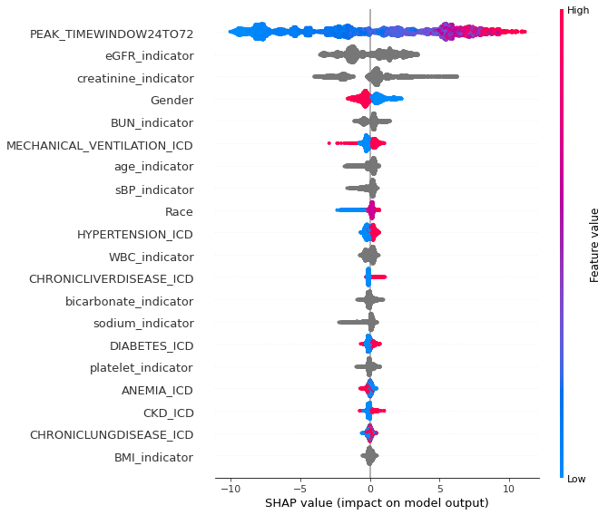

```python
shap.summary_plot(shap_values_1, X)
```